# Detection of Annotation Anomalies

Anthony Christidis, Andrew Ghazi, Smriti Chawla, Nitesh Turaga, Ludwig Geistlinger and Robert Gentleman

Core for Computational Biomedicine, Harvard Medical School

anthony-alexander_christidis@hms.harvard.edu

25 August 2024

#### Package

scDiagnostics 0.99.6

# 1 Introduction

This vignette demonstrates the use of two functions, `calculateCellDistances` and `calculateCellDistancesSimilarity`, to analyze the distances between cells in query and reference datasets and to measure the similarity of density distributions. These functions are useful for investigating how cells in different datasets relate to each other, particularly in the context of identifying anomalies and understanding distribution overlaps.

# 2 Datasets

In the context of the `scDiagnostics` package, the following datasets illustrate the application of these tools:

- **reference_data**: A curated and processed dataset containing expert-assigned cell type annotations. This dataset serves as a reference for comparison and can be used alone to detect anomalies within the reference annotations.
- **query_data**: A dataset that also includes expert-assigned cell type annotations, but additionally features annotations generated by the `SingleR` package. This allows for the comparison of expert annotations with those produced by an automated method to detect inconsistencies or anomalies.

```r
# Load library
library(scDiagnostics)

# Load datasets
data("reference_data")
data("query_data")
```

# 3 Computing Cell Distances

The `calculateCellDistances` function calculates Euclidean distances between cells within the reference dataset and between query cells and reference cells. This helps in understanding how closely related cells are within and across datasets based on their principal component (PC) scores.

## 3.1 Function Usage

```r
# Compute cell distances
distance_data <- calculateCellDistances(query_data = query_data,
                                        reference_data = reference_data,
                                        query_cell_type_col = "SingleR_annotation",
                                        ref_cell_type_col = "expert_annotation",
                                        pc_subset = 1:10)
```

In the code above: - `query_data` and reference_data: These are SingleCellExperiment objects containing the respective datasets for analysis. - `query_cell_type_col` and ref_cell_type_col: These arguments specify the columns in the colData of each dataset that contain cell type annotations. - `pc_subset`: Specifies which principal components (1 to 10) are used to compute distances. PCA is applied for dimensionality reduction before calculating distances.

## 3.2 Output

The output `distance_data` is a list where each entry contains:

- `ref_distances`: Pairwise distances within the reference dataset for each cell type.
- `query_to_ref_distances`: Distances from each query cell to all reference cells for each cell type.

## 3.3 Example Workflow

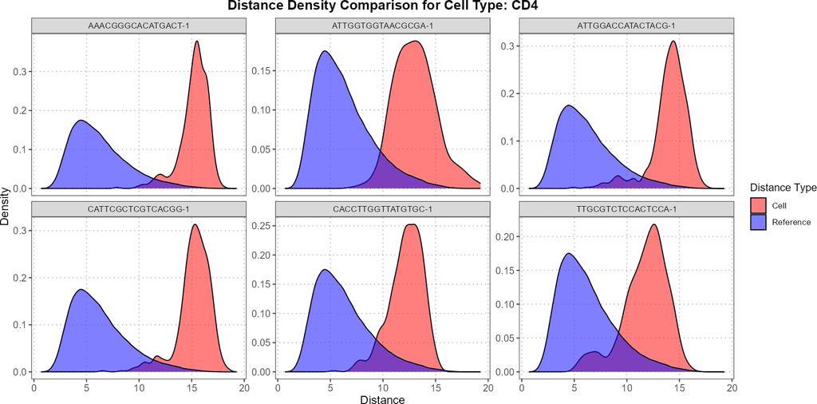

```r
# Identify top 6 anomalies for CD4 cells
cd4_anomalies <- detectAnomaly(
  reference_data = reference_data,
  query_data = query_data,
  query_cell_type_col = "SingleR_annotation",
  ref_cell_type_col = "expert_annotation",
  pc_subset = 1:10,
  n_tree = 500,
  anomaly_treshold = 0.5)

# Top 6 CD4 anomalies
cd4_top6_anomalies <- names(sort(cd4_anomalies$CD4$query_anomaly_scores, decreasing = TRUE)[1:6])

# Plot distances for CD4 and CD8 cells
plot(distance_data, ref_cell_type = "CD4", cell_names = cd4_top6_anomalies)
```

For CD4 cells, you might observe that the query cells are located much further away from the reference cells, indicating a significant divergence in their density distributions. This suggests that the CD4 query cells are less similar to the CD4 reference cells, showing greater variation or potential anomalies.

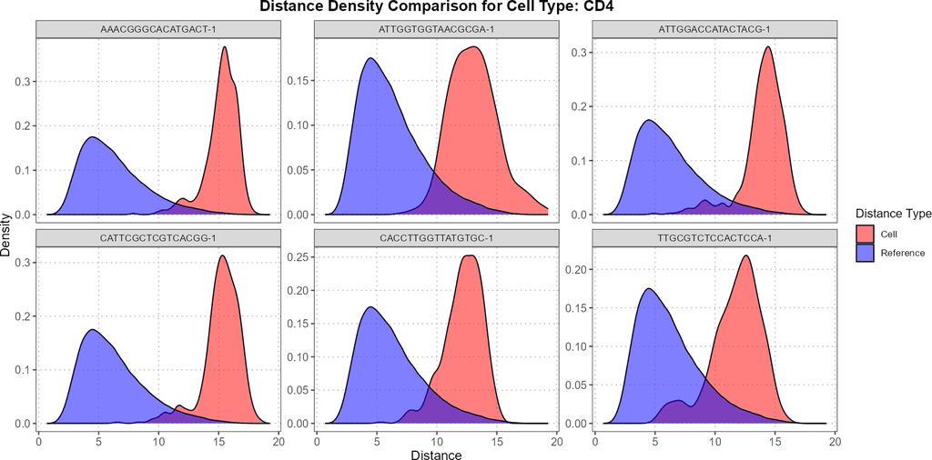

```r
# Plot distances for CD8 cells
plot(distance_data, ref_cell_type = "CD4", cell_names = cd4_top6_anomalies)
```

# 4 Calculating Similarity Measures

The `calculateCellDistancesSimilarity` function measures how similar the density distributions of query cells are to those in the reference dataset. It computes **Bhattacharyya coefficients** and **Hellinger distances**, which quantify the overlap between the distributions.

The Bhattacharyya coefficient and Hellinger distance are two measures used to quantify the similarity between probability distributions. The Bhattacharyya coefficient ranges from 0 to 1, where a value closer to 1 indicates higher similarity between distributions, while a value closer to 0 suggests greater dissimilarity. The Hellinger distance, also ranging from 0 to 1, reflects the divergence between distributions, with lower values indicating greater similarity and higher values showing more distinct distributions. In the context of comparing query cells to reference cells, a high Bhattacharyya coefficient and a low Hellinger distance both suggest that the query cells have density profiles similar to those in the reference dataset, which can be desirable depending on the experimental objectives.

```r
# Compute similarity measures for top 6 CD4 anomalies
overlap_measures <- calculateCellDistancesSimilarity(
  query_data = query_data,
  reference_data = reference_data,
  cell_names = cd4_top6_anomalies,
  query_cell_type_col = "SingleR_annotation",
  ref_cell_type_col = "expert_annotation",
  pc_subset = 1:10)
overlap_measures
```

```
#> $bhattacharyya_coef
#>                 Cell B_and_plasma       CD8       CD4    Myeloid
#> 1 AAACGGGCACATGACT-1    0.1925182 0.7128711 0.2116577 0.07436962
#> 2 ATTGGTGGTAACGCGA-1    0.4236378 0.3799852 0.3830778 0.27169272
#> 3 ATTGGACCATACTACG-1    0.2097601 0.8765028 0.3656771 0.09452698
#> 4 CATTCGCTCGTCACGG-1    0.1363147 0.7006176 0.2448559 0.05778528
#> 5 CACCTTGGTTATGTGC-1    0.2452612 0.9885897 0.4514740 0.04147370
#> 6 TTGCGTCTCCACTCCA-1    0.2741303 0.9457587 0.5678963 0.12581074
#>
#> $hellinger_dist
#>                 Cell B_and_plasma       CD8       CD4   Myeloid
#> 1 AAACGGGCACATGACT-1    0.8985999 0.5358441 0.8878864 0.9620969
#> 2 ATTGGTGGTAACGCGA-1    0.7591853 0.7874102 0.7854439 0.8534092
#> 3 ATTGGACCATACTACG-1    0.8889544 0.3514217 0.7964439 0.9515635
#> 4 CATTCGCTCGTCACGG-1    0.9293467 0.5471585 0.8689903 0.9706775
#> 5 CACCTTGGTTATGTGC-1    0.8687570 0.1068190 0.7406254 0.9790436
#> 6 TTGCGTCTCCACTCCA-1    0.8519799 0.2328977 0.6573459 0.9349809
```

# 5 Conclusion

This vignette illustrates how to leverage the `calculateCellDistances` and `calculateCellDistancesSimilarity` functions to analyze cell distances and distribution similarities in single-cell datasets. By calculating Euclidean distances between cells within and across datasets, you gain insights into how closely related cells are in the PCA-reduced space. The subsequent step of computing similarity measures, such as Bhattacharyya coefficients and Hellinger distances, allows for a deeper understanding of how similar the density distributions of query cells are to those in the reference dataset.